## Example 1

- Longley’s Economic Regression Data: A data frame with 7 economical variables, observed yearly from # 1947 to 1962 (n=16).
- GNP.deflator: GNP implicit price deflator (1954=100)
- GNP: Gross National Product.
- Unemployed: number of unemployed.
- Armed.Forces: number of people in the armed forces.
- Population: ‘noninstitutionalized’ population ≥ 14 years of age.
- Year
- Employed: number of people employed.

```r
library(faraway)
data("longley")
head(longley)
```

```
##      GNP.deflator     GNP Unemployed Armed.Forces Population Year Employed
## 1947         83.0 234.289      235.6        159.0    107.608 1947   60.323
## 1948         88.5 259.426      232.5        145.6    108.632 1948   61.122
## 1949         88.2 258.054      368.2        161.6    109.773 1949   60.171
## 1950         89.5 284.599      335.1        165.0    110.929 1950   61.187
## 1951         96.2 328.975      209.9        309.9    112.075 1951   63.221
## 1952         98.1 346.999      193.2        359.4    113.270 1952   63.639
```

```r
g = lm(Employed ~ GNP + Population, data=longley)
summary(g)
```

```
##
## Call:
## lm(formula = Employed ~ GNP + Population, data = longley)
##
## Residuals:
##      Min       1Q   Median       3Q      Max
## -0.80899 -0.33282 -0.02329  0.25895  1.08800
##
## Coefficients:
##             Estimate Std. Error t value Pr(>|t|)
## (Intercept) 88.93880   13.78503   6.452 2.16e-05 ***
## GNP          0.06317    0.01065   5.933 4.96e-05 ***
## Population  -0.40974    0.15214  -2.693   0.0184 *
## ---
## Signif. codes:  0 '***' 0.001 '**' 0.01 '*' 0.05 '.' 0.1 ' ' 1
##
## Residual standard error: 0.5459 on 13 degrees of freedom
## Multiple R-squared:  0.9791, Adjusted R-squared:  0.9758
## F-statistic: 303.9 on 2 and 13 DF,  p-value: 1.221e-11
```

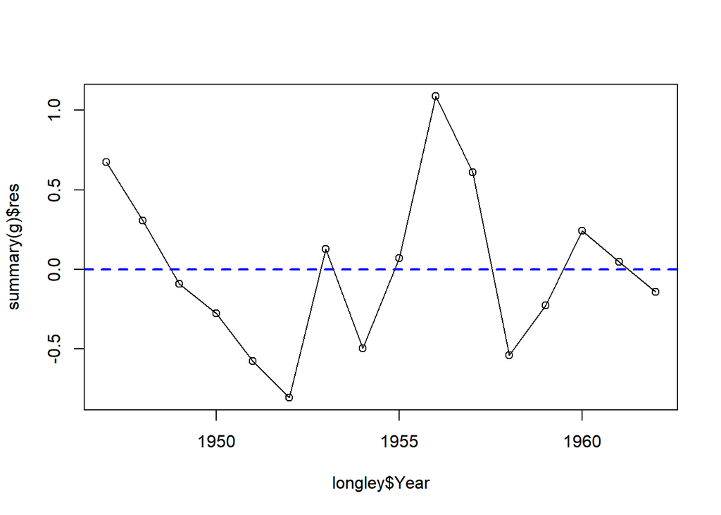

```r
plot(longley$Year, summary(g)$res, type='o')
abline(h=0, lty=2, col="blue", lwd=2)
```

```r
library(lmtest)
dwtest(g)
```

```
##
##  Durbin-Watson test
##
## data:  g
## DW = 1.3015, p-value = 0.02245
## alternative hypothesis: true autocorrelation is greater than 0
```

```r
#D-W test shows the errors are signifficantly correlated
#Solution: Fit a Regression with autocorrelated errors.
library(nlme)
g = gls(Employed ~ GNP + Population, correlation = corAR1(form= ~ Year), data=longley)
summary(g)
```

```
## Generalized least squares fit by REML
##   Model: Employed ~ GNP + Population
##   Data: longley
##        AIC      BIC    logLik
##   44.66377 47.48852 -17.33188
##
## Correlation Structure: AR(1)
##  Formula: ~Year
##  Parameter estimate(s):
##       Phi
## 0.6441692
##
## Coefficients:
##                 Value Std.Error   t-value p-value
## (Intercept) 101.85813 14.198932  7.173647  0.0000
## GNP           0.07207  0.010606  6.795485  0.0000
## Population   -0.54851  0.154130 -3.558778  0.0035
##
##  Correlation:
##            (Intr) GNP
## GNP         0.943
## Population -0.997 -0.966
##
## Standardized residuals:
##        Min         Q1        Med         Q3        Max
## -1.5924564 -0.5447822 -0.1055401  0.3639202  1.3281898
##
## Residual standard error: 0.689207
## Degrees of freedom: 16 total; 13 residual
```

```r
g1 = gls(Employed ~ GNP + Population, correlation = corARMA(p=1), data=longley)
summary(g1) # should return the same result as corAR1.
```

```
## Generalized least squares fit by REML
##   Model: Employed ~ GNP + Population
##   Data: longley
##        AIC      BIC    logLik
##   44.66377 47.48852 -17.33188
##
## Correlation Structure: AR(1)
##  Formula: ~1
##  Parameter estimate(s):
##       Phi
## 0.6441692
##
## Coefficients:
##                 Value Std.Error   t-value p-value
## (Intercept) 101.85813 14.198932  7.173647  0.0000
## GNP           0.07207  0.010606  6.795485  0.0000
## Population   -0.54851  0.154130 -3.558778  0.0035
##
##  Correlation:
##            (Intr) GNP
## GNP         0.943
## Population -0.997 -0.966
##
## Standardized residuals:
##        Min         Q1        Med         Q3        Max
## -1.5924564 -0.5447822 -0.1055401  0.3639202  1.3281898
##
## Residual standard error: 0.689207
## Degrees of freedom: 16 total; 13 residual
```

```r
intervals(g)
```

```
## Approximate 95% confidence intervals
##
##  Coefficients:
##                   lower         est.       upper
## (Intercept) 71.18320460 101.85813305 132.5330615
## GNP          0.04915865   0.07207088   0.0949831
## Population  -0.88149053  -0.54851350  -0.2155365
## attr(,"label")
## [1] "Coefficients:"
##
##  Correlation structure:
##          lower      est.     upper
## Phi -0.4432383 0.6441692 0.9645041
## attr(,"label")
## [1] "Correlation structure:"
##
##  Residual standard error:
##     lower      est.     upper
## 0.2477527 0.6892070 1.9172599
```

```r
# D-W test shows that the errors are signifficantly correlated,
# but the AR(1) coeff rho is not signifficant. Is there a contradiction?
```

## Example 2: Lack of fit ($\sigma^2$ known)

This is an example from an experiment to study the interaction of certain kinds of elementary particles on collision with proton targets. The experiment was designed to test certain theories about the nature of the strong interaction. The cross-section (crossx) variable is believed to be linearly related to the inverse of the energy (energy - has already been inverted). At each level of the momentum, a very large number of observations were taken so that it was possible to accurately estimate the standard deviation of the response (sd).

```r
data("strongx")
names(strongx)
```

```
## [1] "momentum" "energy"   "crossx"   "sd"
```

```r
g=lm(crossx ~ energy, strongx, weights=1/sd^2)
summary(g)
```

```
##
## Call:
## lm(formula = crossx ~ energy, data = strongx, weights = 1/sd^2)
##
## Weighted Residuals:
##     Min      1Q  Median      3Q     Max
## -2.3230 -0.8842  0.0000  1.3900  2.3353
##
## Coefficients:
##             Estimate Std. Error t value Pr(>|t|)
## (Intercept)  148.473      8.079   18.38 7.91e-08 ***
## energy       530.835     47.550   11.16 3.71e-06 ***
## ---
## Signif. codes:  0 '***' 0.001 '**' 0.01 '*' 0.05 '.' 0.1 ' ' 1
##
## Residual standard error: 1.657 on 8 degrees of freedom
## Multiple R-squared:  0.9397, Adjusted R-squared:  0.9321
## F-statistic: 124.6 on 1 and 8 DF,  p-value: 3.71e-06
```

```r
gu=lm(crossx ~ energy, strongx);
summary(gu)
```

```
##
## Call:
## lm(formula = crossx ~ energy, data = strongx)
##
## Residuals:
##     Min      1Q  Median      3Q     Max
## -14.773  -9.319  -2.829   5.571  19.817
##
## Coefficients:
##             Estimate Std. Error t value Pr(>|t|)
## (Intercept)   135.00      10.08    13.4 9.21e-07 ***
## energy        619.71      47.68    13.0 1.16e-06 ***
## ---
## Signif. codes:  0 '***' 0.001 '**' 0.01 '*' 0.05 '.' 0.1 ' ' 1
##
## Residual standard error: 12.69 on 8 degrees of freedom
## Multiple R-squared:  0.9548, Adjusted R-squared:  0.9491
## F-statistic: 168.9 on 1 and 8 DF,  p-value: 1.165e-06
```

```r
# Lack-of-fit Test
1 - pchisq(summary(g)$sig^2*8, 8) #Conclude that there is lack of fit
```

```
## [1] 0.005004345
```

```r
# How do we estimate sigma-square?
cbind(summary(gu)$sig^2, sum(gu$res^2)/8)
```

```
##          [,1]     [,2]
## [1,] 161.1616 161.1616
```

```r
# For WLS, these two do not agree.
summary(g)$sig^2
```

```
## [1] 2.744081
```

```r
sum(g$res^2)/8
```

```
## [1] 248.7354
```

```r
sum(g$res^2/strongx$sd^2)/8
```

```
## [1] 2.744081
```

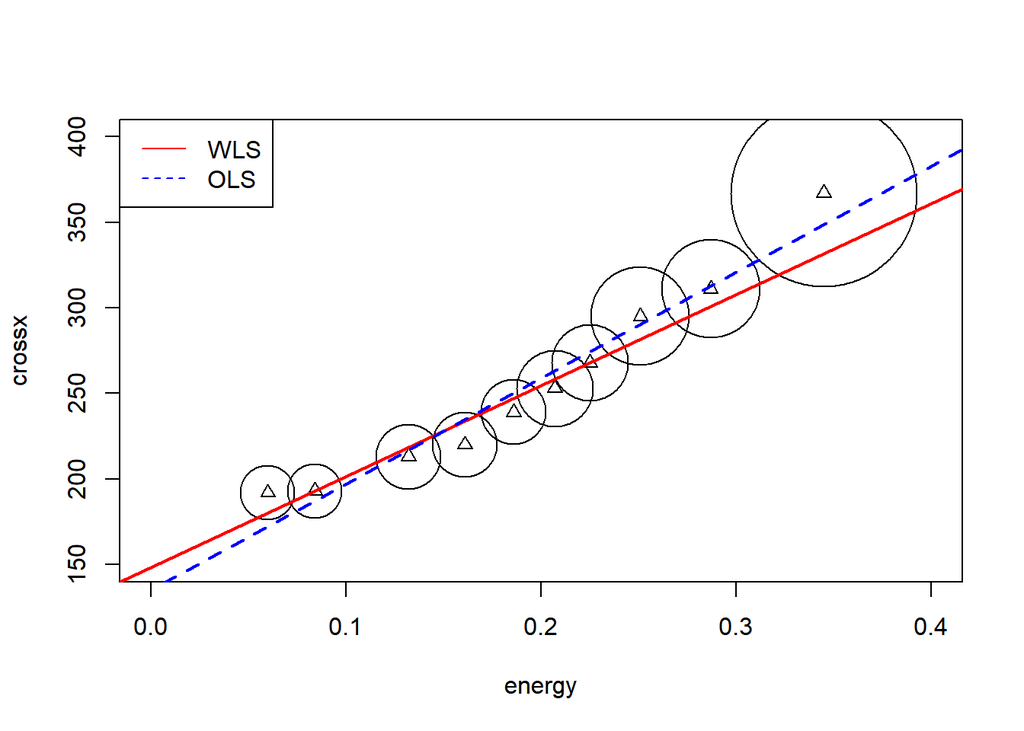

```r
plot(crossx ~ energy, data=strongx, cex=sd, xlim=c(0, 0.4), ylim=c(150, 400));
points(crossx ~ energy, data=strongx, pch=2)
abline(g, col="red", lty=1, lwd=2);
abline(gu, col="blue", lty=2, lwd=2);
legend("topleft", col=c("red", "blue"), lty=c(1,2), legend=c("WLS", "OLS"))
```

```r
# Then try polynomials.
g2 =lm(crossx ~ energy + I(energy^2) , strongx, weights=1/sd^2)
anova(g, g2)
```

```
## Analysis of Variance Table
##
## Model 1: crossx ~ energy
## Model 2: crossx ~ energy + I(energy^2)
##   Res.Df     RSS Df Sum of Sq      F    Pr(>F)
## 1      8 21.9526
## 2      7  3.2255  1    18.727 40.641 0.0003761 ***
## ---
## Signif. codes:  0 '***' 0.001 '**' 0.01 '*' 0.05 '.' 0.1 ' ' 1
```

## Example 3: Lack of fit ($\sigma^2$ unknown)

Data consist of thirteen specimens of 90/10 Cu-Ni alloys with varying iron content in percent. The specimens were submerged in sea water for 60 days and the weight loss due to corrosion # was recorded in units of milligrams per square decimeter per day.

- Fe Iron content in percent loss
- Weight loss in mg per square decimeter per day

```r
data("corrosion")
corrosion[order(corrosion$Fe),]
```

```
##      Fe  loss
## 1  0.01 127.6
## 6  0.01 130.1
## 11 0.01 128.0
## 2  0.48 124.0
## 7  0.48 122.0
## 3  0.71 110.8
## 9  0.71 113.1
## 4  0.95 103.9
## 5  1.19 101.5
## 8  1.44  92.3
## 12 1.44  91.4
## 10 1.96  83.7
## 13 1.96  86.2
```

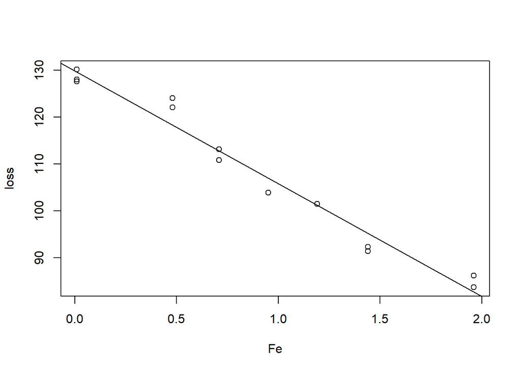

```r
g = lm(loss ~ Fe, data=corrosion);
plot(loss~Fe, data=corrosion); abline(coef(g));
```

```r
ga=lm(loss ~ factor(Fe), data=corrosion);
cbind(corrosion, ga$fitted)[order(corrosion$Fe),]
```

```
##      Fe  loss ga$fitted
## 1  0.01 127.6  128.5667
## 6  0.01 130.1  128.5667
## 11 0.01 128.0  128.5667
## 2  0.48 124.0  123.0000
## 7  0.48 122.0  123.0000
## 3  0.71 110.8  111.9500
## 9  0.71 113.1  111.9500
## 4  0.95 103.9  103.9000
## 5  1.19 101.5  101.5000
## 8  1.44  92.3   91.8500
## 12 1.44  91.4   91.8500
## 10 1.96  83.7   84.9500
## 13 1.96  86.2   84.9500
```

```r
anova(g, ga)
```

```
## Analysis of Variance Table
##
## Model 1: loss ~ Fe
## Model 2: loss ~ factor(Fe)
##   Res.Df     RSS Df Sum of Sq      F   Pr(>F)
## 1     11 102.850
## 2      6  11.782  5    91.069 9.2756 0.008623 **
## ---
## Signif. codes:  0 '***' 0.001 '**' 0.01 '*' 0.05 '.' 0.1 ' ' 1
```

```r
1-pf(9.2756,5,6) #There is lack of fit
```

```
## [1] 0.008622884
```